# R Notebook

```r
library(dplyr)
library(ggplot2)
library(readr)
library(stringr)
library(ROSE)
library(ranger)
library(pROC)
training <- read_csv("C:/Users/fvoss/Google Drive/Uni_5_Semester/Studienarbeit/training.csv",
    col_types = cols(RefId = col_number(),
        VehYear = col_number(), VehicleAge = col_number(),
        WheelTypeID = col_number(), VehOdo = col_number(),
        MMRAcquisitionAuctionAveragePrice = col_number(),
        MMRAcquisitionAuctionCleanPrice = col_number(),
        MMRAcquisitionRetailAveragePrice = col_number(),
        MMRAcquisitonRetailCleanPrice = col_number(),
        MMRCurrentAuctionAveragePrice = col_number(),
        MMRCurrentAuctionCleanPrice = col_number(),
        MMRCurrentRetailAveragePrice = col_number(),
        MMRCurrentRetailCleanPrice = col_number(),
        BYRNO = col_number(), VNZIP1 = col_number(),
        VehBCost = col_number(), IsOnlineSale = col_number(),
        WarrantyCost = col_number()))
```

[output not shown]

Data Understanding

Dieser Abschnitt dient dazu, die vorhandenen Daten zu verstehen und zu interpretieren. Zunächst wird die Summary des Trainingdatensatzes betrachtet:

```r
summary(training)
```

```
     RefId          IsBadBuy      PurchDate           Auction             VehYear       VehicleAge        Make              Model
 Min.   :    1   Min.   :0.000   Length:72983       Length:72983       Min.   :2001   Min.   :0.000   Length:72983       Length:72983
 1st Qu.:18258   1st Qu.:0.000   Class :character   Class :character   1st Qu.:2004   1st Qu.:3.000   Class :character   Class :character
 Median :36514   Median :0.000   Mode  :character   Mode  :character   Median :2005   Median :4.000   Mode  :character   Mode  :character
 Mean   :36511   Mean   :0.123                                         Mean   :2005   Mean   :4.177
 3rd Qu.:54765   3rd Qu.:0.000                                         3rd Qu.:2007   3rd Qu.:5.000
 Max.   :73014   Max.   :1.000                                         Max.   :2010   Max.   :9.000

     Trim             SubModel            Color           Transmission        WheelTypeID     WheelType             VehOdo       Nationality
 Length:72983       Length:72983       Length:72983       Length:72983       Min.   :0.000   Length:72983       Min.   :  4825   Length:72983
 Class :character   Class :character   Class :character   Class :character   1st Qu.:1.000   Class :character   1st Qu.: 61837   Class :character
 Mode  :character   Mode  :character   Mode  :character   Mode  :character   Median :1.000   Mode  :character   Median : 73361   Mode  :character
                                                                             Mean   :1.494                      Mean   : 71500
                                                                             3rd Qu.:2.000                      3rd Qu.: 82436
                                                                             Max.   :3.000                      Max.   :115717
                                                                             NA's   :3169
     Size           TopThreeAmericanName MMRAcquisitionAuctionAveragePrice MMRAcquisitionAuctionCleanPrice MMRAcquisitionRetailAveragePrice
 Length:72983       Length:72983         Min.   :    0                     Min.   :    0                   Min.   :    0
 Class :character   Class :character     1st Qu.: 4273                     1st Qu.: 5406                   1st Qu.: 6280
 Mode  :character   Mode  :character     Median : 6097                     Median : 7303                   Median : 8444
                                         Mean   : 6129                     Mean   : 7374                   Mean   : 8497
                                         3rd Qu.: 7765                     3rd Qu.: 9021                   3rd Qu.:10651
                                         Max.   :35722                     Max.   :36859                   Max.   :39080
                                         NA's   :18                        NA's   :18                      NA's   :18
 MMRAcquisitonRetailCleanPrice MMRCurrentAuctionAveragePrice MMRCurrentAuctionCleanPrice MMRCurrentRetailAveragePrice MMRCurrentRetailCleanPrice
 Min.   :    0                 Min.   :    0                 Min.   :    0               Min.   :    0                Min.   :    0
 1st Qu.: 7493                 1st Qu.: 4275                 1st Qu.: 5414               1st Qu.: 6536                1st Qu.: 7784
 Median : 9789                 Median : 6062                 Median : 7313               Median : 8729                Median :10103
 Mean   : 9851                 Mean   : 6132                 Mean   : 7391               Mean   : 8776                Mean   :10145
 3rd Qu.:12088                 3rd Qu.: 7736                 3rd Qu.: 9013               3rd Qu.:10911                3rd Qu.:12309
 Max.   :41482                 Max.   :35722                 Max.   :36859               Max.   :39080                Max.   :41062
 NA's   :18                    NA's   :315                   NA's   :315                 NA's   :315                  NA's   :315
  PRIMEUNIT           AUCGUART             BYRNO           VNZIP1          VNST              VehBCost      IsOnlineSale      WarrantyCost
 Length:72983       Length:72983       Min.   :  835   Min.   : 2764   Length:72983       Min.   :    1   Min.   :0.00000   Min.   : 462
 Class :character   Class :character   1st Qu.:17212   1st Qu.:32124   Class :character   1st Qu.: 5435   1st Qu.:0.00000   1st Qu.: 837
 Mode  :character   Mode  :character   Median :19662   Median :73108   Mode  :character   Median : 6700   Median :0.00000   Median :1155
                                       Mean   :26346   Mean   :58043                      Mean   : 6731   Mean   :0.02528   Mean   :1277
                                       3rd Qu.:22808   3rd Qu.:80022                      3rd Qu.: 7900   3rd Qu.:0.00000   3rd Qu.:1623
                                       Max.   :99761   Max.   :99224                      Max.   :45469   Max.   :1.00000   Max.   :7498
```

Danach wird geprüft, ob die angegebenen Datentypen auch zu den Werten der Daten passen.

```r
head(training)
```

| RefId | IsBadBuy | PurchDate | Auction | VehYear | VehicleAge | Make | Model | Trim | SubModel | Color | Transmission | WheelTypeID | WheelType | VehOdo | Nationality | Size | TopThreeAmericanName | MMRAcquisitionAuctionAveragePrice | MMRAcquisitionAuctionCleanPrice | MMRAcquisitionRetailAveragePrice | MMRAcquisitonRetailCleanPrice | MMRCurrentAuctionAveragePrice | MMRCurrentAuctionCleanPrice | MMRCurrentRetailAveragePrice | MMRCurrentRetailCleanPrice | PRIMEUNIT | AUCGUART | BYRNO | VNZIP1 | … |
| --- | --- | --- | --- | --- | --- | --- | --- | --- | --- | --- | --- | --- | --- | --- | --- | --- | --- | --- | --- | --- | --- | --- | --- | --- | --- | --- | --- | --- | --- | --- |
| 1 | 0 | 12/7/2009 | ADESA | 2006 | 3 | MAZDA | MAZDA3 | i | 4D SEDAN I | RED | AUTO | 1 | Alloy | 89046 | OTHER ASIAN | MEDIUM | OTHER | 8155 | 9829 | 11636 | 13600 | 7451 | 8552 | 11597 | 12409 | NULL | NULL | 21973 | 33619 | … |
| 2 | 0 | 12/7/2009 | ADESA | 2004 | 5 | DODGE | 1500 RAM PICKUP 2WD | ST | QUAD CAB 4.7L SLT | WHITE | AUTO | 1 | Alloy | 93593 | AMERICAN | LARGE TRUCK | CHRYSLER | 6854 | 8383 | 10897 | 12572 | 7456 | 9222 | 11374 | 12791 | NULL | NULL | 19638 | 33619 | … |
| 3 | 0 | 12/7/2009 | ADESA | 2005 | 4 | DODGE | STRATUS V6 | SXT | 4D SEDAN SXT FFV | MAROON | AUTO | 2 | Covers | 73807 | AMERICAN | MEDIUM | CHRYSLER | 3202 | 4760 | 6943 | 8457 | 4035 | 5557 | 7146 | 8702 | NULL | NULL | 19638 | 33619 | … |
| 4 | 0 | 12/7/2009 | ADESA | 2004 | 5 | DODGE | NEON | SXT | 4D SEDAN | SILVER | AUTO | 1 | Alloy | 65617 | AMERICAN | COMPACT | CHRYSLER | 1893 | 2675 | 4658 | 5690 | 1844 | 2646 | 4375 | 5518 | NULL | NULL | 19638 | 33619 | … |
| 5 | 0 | 12/7/2009 | ADESA | 2005 | 4 | FORD | FOCUS | ZX3 | 2D COUPE ZX3 | SILVER | MANUAL | 2 | Covers | 69367 | AMERICAN | COMPACT | FORD | 3913 | 5054 | 7723 | 8707 | 3247 | 4384 | 6739 | 7911 | NULL | NULL | 19638 | 33619 | … |
| 6 | 0 | 12/7/2009 | ADESA | 2004 | 5 | MITSUBISHI | GALANT 4C | ES | 4D SEDAN ES | WHITE | AUTO | 2 | Covers | 81054 | OTHER ASIAN | MEDIUM | OTHER | 3901 | 4908 | 6706 | 8577 | 4709 | 5827 | 8149 | 9451 | NULL | NULL | 19638 | 33619 | … |

Die Spalten, die den Preis enthalten, sind falsch dargestellt und müssen in “double” umgewandelt werden. Daher wird zuerst geschaut, ob nicht konvertierbare Einträge vorhanden sind:

```r
filteredData <- training %>%
  filter(MMRAcquisitionAuctionAveragePrice != "NULL")%>%
  filter(MMRAcquisitionAuctionCleanPrice != "NULL")%>%
  filter(MMRAcquisitionRetailAveragePrice != "NULL")%>%
  filter(MMRAcquisitonRetailCleanPrice != "NULL")%>%
  filter(MMRCurrentAuctionAveragePrice != "NULL")%>%
  filter(MMRCurrentAuctionCleanPrice != "NULL")%>%
  filter(MMRCurrentRetailAveragePrice != "NULL")%>%
  filter(MMRCurrentRetailCleanPrice != "NULL")
```

Durch diese Filterung fallen 315 Datensätze weg, was im Verhältnis zu dem großen Datensatz kaum Auswirkungen hat. Weiter werden die Spalten in Typ double geändert.

```r
filteredData$MMRAcquisitionAuctionAveragePrice <- as.integer(as.character(filteredData$MMRAcquisitionAuctionAveragePrice))
filteredData$MMRAcquisitionAuctionCleanPrice <- as.numeric(as.character(filteredData$MMRAcquisitionAuctionCleanPrice))
filteredData$MMRAcquisitionRetailAveragePrice <- as.numeric(as.character(filteredData$MMRAcquisitionRetailAveragePrice))
filteredData$MMRAcquisitonRetailCleanPrice <- as.numeric(as.character(filteredData$MMRAcquisitonRetailCleanPrice))
filteredData$MMRCurrentAuctionAveragePrice <- as.numeric(as.character(filteredData$MMRCurrentAuctionAveragePrice))
filteredData$MMRCurrentAuctionCleanPrice <- as.numeric(as.character(filteredData$MMRCurrentAuctionCleanPrice))
filteredData$MMRCurrentRetailAveragePrice <- as.numeric(as.character(filteredData$MMRCurrentRetailAveragePrice))
filteredData$MMRCurrentRetailCleanPrice <- as.numeric(as.character(filteredData$MMRCurrentRetailCleanPrice))
```

Nach Umwandlung erneut Summary aufrufen:

```r
summary(filteredData)
```

[output not shown]

Das Attribut “WheelId” beinhaltet noch 3167 NA’S. Nach der Umwandlung sind die Zahlen nun richtig dargestellt. Die numerischen Werte werden ausgewählt, um eine Korrelationsmatrix zu erstellen:

```r
matrixData <- filteredData %>%
  select(IsBadBuy, VehYear, VehicleAge, WheelTypeID, VehOdo, MMRAcquisitionAuctionAveragePrice, MMRAcquisitionAuctionCleanPrice, MMRAcquisitionRetailAveragePrice, MMRAcquisitonRetailCleanPrice, MMRCurrentAuctionAveragePrice, MMRCurrentAuctionCleanPrice, MMRCurrentRetailAveragePrice, MMRCurrentRetailCleanPrice, BYRNO, VNZIP1, VehBCost, WarrantyCost)


cor(matrixData, method ="pearson")
```

```
                                      IsBadBuy     VehYear  VehicleAge WheelTypeID      VehOdo MMRAcquisitionAuctionAveragePrice
IsBadBuy                           1.000000000 -0.15902936  0.16736358          NA  0.08240372                       -0.10906700
VehYear                           -0.159029364  1.00000000 -0.95788891          NA -0.28160535                        0.58046078
VehicleAge                         0.167363582 -0.95788891  1.00000000          NA  0.31769856                       -0.56521797
WheelTypeID                                 NA          NA          NA           1          NA                                NA
VehOdo                             0.082403724 -0.28160535  0.31769856          NA  1.00000000                       -0.01537265
MMRAcquisitionAuctionAveragePrice -0.109066996  0.58046078 -0.56521797          NA -0.01537265                        1.00000000
MMRAcquisitionAuctionCleanPrice   -0.102903255  0.53259272 -0.51878104          NA  0.02573019                        0.99040542
MMRAcquisitionRetailAveragePrice  -0.087251724  0.58096419 -0.46079476          NA  0.03263518                        0.91041701
MMRAcquisitonRetailCleanPrice     -0.083610745  0.53927991 -0.42669282          NA  0.06411404                        0.91038016
MMRCurrentAuctionAveragePrice     -0.109111978  0.59081973 -0.57560713          NA -0.02856776                        0.93781705
MMRCurrentAuctionCleanPrice       -0.104020179  0.54842630 -0.53250543          NA  0.01210709                        0.93249198
MMRCurrentRetailAveragePrice      -0.103913761  0.59848991 -0.50406159          NA  0.01581118                        0.87175541
MMRCurrentRetailCleanPrice        -0.100245283  0.55866898 -0.46935906          NA  0.04800479                        0.87104184
BYRNO                             -0.060880681  0.27769061 -0.26492742          NA -0.28583957                        0.10570885
VNZIP1                             0.005997049  0.06768106 -0.07418371          NA -0.05234984                        0.04540483
VehBCost                          -0.099613648  0.34898421 -0.31156956          NA -0.06074488                        0.78958892
WarrantyCost                       0.051896288 -0.26782346  0.25829919          NA  0.41120311                       -0.04991096
                                  MMRAcquisitionAuctionCleanPrice MMRAcquisitionRetailAveragePrice MMRAcquisitonRetailCleanPrice
IsBadBuy                                              -0.10290325                      -0.08725172                   -0.08361074
VehYear                                                0.53259272                       0.58096419                    0.53927991
VehicleAge                                            -0.51878104                      -0.46079476                   -0.42669282
WheelTypeID                                                    NA                               NA                            NA
VehOdo                                                 0.02573019                       0.03263518                    0.06411404
MMRAcquisitionAuctionAveragePrice                      0.99040542                       0.91041701                    0.91038016
MMRAcquisitionAuctionCleanPrice                        1.00000000                       0.90265455                    0.91826588
MMRAcquisitionRetailAveragePrice                       0.90265455                       1.00000000                    0.99021448
MMRAcquisitonRetailCleanPrice                          0.91826588                       0.99021448                    1.00000000
MMRCurrentAuctionAveragePrice                          0.92361024                       0.85164677                    0.84691415
MMRCurrentAuctionCleanPrice                            0.93211374                       0.84940671                    0.85568896
MMRCurrentRetailAveragePrice                           0.86071619                       0.91310820                    0.90318812
MMRCurrentRetailCleanPrice                             0.87120321                       0.90605437                    0.90681036
BYRNO                                                  0.06114035                       0.10614396                    0.06875514
VNZIP1                                                 0.04057328                       0.03539716                    0.03133457
VehBCost                                               0.78131882                       0.74581711                    0.74480002
WarrantyCost                                          -0.02041217                      -0.05318873                   -0.02688050
                                  MMRCurrentAuctionAveragePrice MMRCurrentAuctionCleanPrice MMRCurrentRetailAveragePrice MMRCurrentRetailCleanPrice
IsBadBuy                                            -0.10911198                 -0.10402018                  -0.10391376                -0.10024528
VehYear                                              0.59081973                  0.54842630                   0.59848991                 0.55866898
VehicleAge                                          -0.57560713                 -0.53250543                  -0.50406159                -0.46935906
```

[output cut: 17 more lines]

```
VehicleAge                        -0.26492742 -0.074183711 -0.31156956   0.25829919
WheelTypeID                                NA           NA          NA           NA
VehOdo                            -0.28583957 -0.052349844 -0.06074488   0.41120311
MMRAcquisitionAuctionAveragePrice  0.10570885  0.045404832  0.78958892  -0.04991096
MMRAcquisitionAuctionCleanPrice    0.06114035  0.040573283  0.78131882  -0.02041217
MMRAcquisitionRetailAveragePrice   0.10614396  0.035397156  0.74581711  -0.05318873
MMRAcquisitonRetailCleanPrice      0.06875514  0.031334569  0.74480002  -0.02688050
MMRCurrentAuctionAveragePrice      0.11136320  0.048965445  0.77873785  -0.05679802
MMRCurrentAuctionCleanPrice        0.06880122  0.043683803  0.77510023  -0.02813066
MMRCurrentRetailAveragePrice       0.11118970  0.039189700  0.75681563  -0.05802485
MMRCurrentRetailCleanPrice         0.07490337  0.034688354  0.75666218  -0.03168320
BYRNO                              1.00000000  0.039086440  0.04426666  -0.08478052
VNZIP1                             0.03908644  1.000000000  0.01687433  -0.03564850
VehBCost                           0.04426666  0.016874331  1.00000000  -0.03288293
WarrantyCost                      -0.08478052 -0.035648495 -0.03288293   1.00000000
```

Beim Betrachten der Summary kommt folgende Vermutung: Datensatz im Hinblick auf das Attribut “IsBadBuy” nicht balanciert. Überprüfe mit Hilfe eines einfachen Plots:

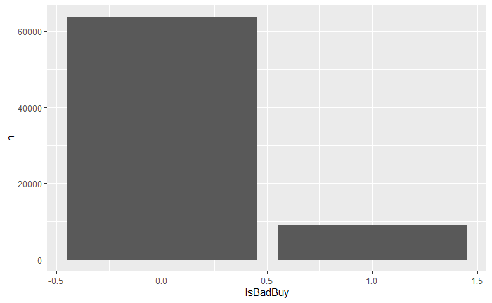

```r
groupedByBad <- filteredData %>%
  select(1,2)
groupedByBad <- groupedByBad %>%
  count(IsBadBuy)

ggplot(data = groupedByBad, mapping=aes(x=IsBadBuy,y=n))+
  geom_bar(stat='identity')
```

```r
head(groupedByBad)
```

| IsBadBuy | n |
| --- | --- |
| 0 | 63724 |
| 1 | 8944 |

Im Weiteren wird die Verteilung des Alters der Fahrzeuge betrachtet:

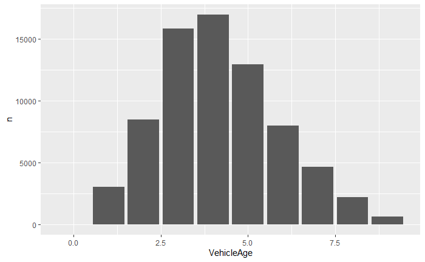

```r
groupedByAge <- filteredData %>%
  select(1,6)%>%
  count(VehicleAge)
ggplot(data = groupedByAge, mapping=aes(x=VehicleAge,y=n))+
  geom_bar(stat='identity')
```

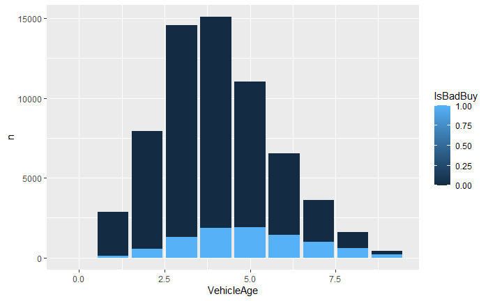

```r
groupedByAgeAndIsBad <- filteredData %>%
  select(1,2,6)%>%
  group_by(IsBadBuy, VehicleAge)%>%
  count(VehicleAge)


ggplot(groupedByAgeAndIsBad, aes(fill=IsBadBuy, y=n, x=VehicleAge)) +
    geom_bar(position="dodge", stat="identity")
```

Um diesen Anstieg der Lemons im Alter besser darzustellen, folgt ein Graph, der das Verhältnis darstellt:

```r
#Gruppiere und berechne Summe aller Fahrzeuge je Alter
```

[output not shown]

```r
groupedByAgeAndIsBad <- groupedByAgeAndIsBad %>%
  group_by(VehicleAge)%>%
  mutate(n2 = sum(n))%>%
  group_by(VehicleAge, add = TRUE)%>%
  mutate(percentageBadBuy=round(100*n/n2,2))%>%
  filter(IsBadBuy == 1)
```

```
The `add` argument of `group_by()` is deprecated as of dplyr 1.0.0.
Please use the `.add` argument instead.
```

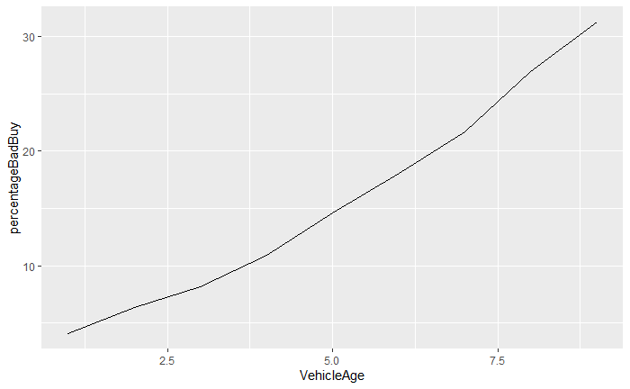

```r
#Plotte die Daten
ggplot(groupedByAgeAndIsBad, aes(x = VehicleAge, y = percentageBadBuy))+
  geom_line()
```

Je älter ein Fahrzeug also ist, umso wahrscheinlicher ist, dass es ein Fehlkauf ist. Weiter wird untersucht, ob die Laufleistung im Bezug auf das Fahrzeugalter eine ähnliche Entwicklung erfährt:

```r
groupedByOdo <- filteredData %>%
  select(1,2,15)

summary(groupedByOdo)
```

```
     RefId          IsBadBuy          VehOdo
 Min.   :    1   Min.   :0.0000   Min.   :  4825
 1st Qu.:18234   1st Qu.:0.0000   1st Qu.: 61874
 Median :36512   Median :0.0000   Median : 73384
 Mean   :36505   Mean   :0.1231   Mean   : 71526
 3rd Qu.:54784   3rd Qu.:0.0000   3rd Qu.: 82452
 Max.   :73014   Max.   :1.0000   Max.   :115717
```

Teile den Datensatz in zwei Gruppen, um den Anteil der Fehlkäufe bei wenig Laufleistung mit denen höherer Laufleistung vergleichen zu können. Nehme hierfür die Hälfte des Datensatzes.

```r
groupedByOdoLow <- groupedByOdo[with(groupedByOdo, order(VehOdo)),][1:36334,] %>%
  group_by(IsBadBuy)%>%
  count(IsBadBuy)%>%
  mutate(split = "LowerOdo")

groupedByOdoHigh <- groupedByOdo[with(groupedByOdo, order(VehOdo)),][36335:72668,] %>%
  group_by(IsBadBuy)%>%
  count(IsBadBuy)%>%
  mutate(split = "UpperOdo")

combined <- bind_rows(groupedByOdoHigh, groupedByOdoLow)
head(combined)
```

| IsBadBuy | n | split |
| --- | --- | --- |
| 0 | 31051 | UpperOdo |
| 1 | 5283 | UpperOdo |
| 0 | 32673 | LowerOdo |
| 1 | 3661 | LowerOdo |

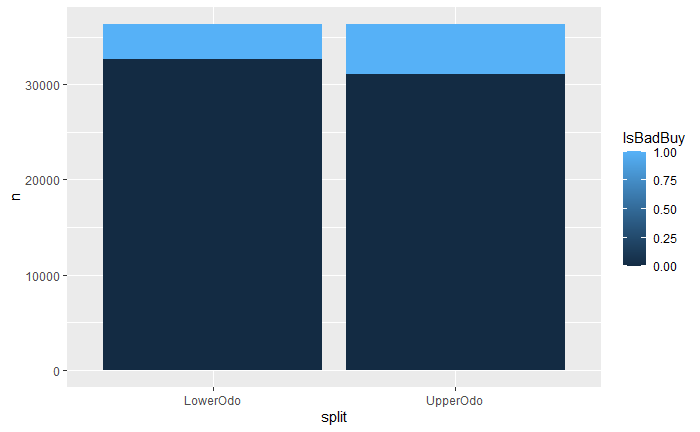

```r
ggplot(combined, aes(fill = IsBadBuy, y=n, x = split)) +
  geom_bar(stat="identity")
```

```r
groupedByMake <- filteredData %>%
  select(1,2,7)%>%
  group_by(IsBadBuy, Make)%>%
  count(Make)%>%
  group_by(Make)%>%
  mutate(n2 = sum(n))%>%
  group_by(Make, add = TRUE)%>%
  mutate(percentageBadBuy=round(100*n/n2,2))%>%
  filter(IsBadBuy == 1)

ggplot(groupedByMake, aes(x = Make, y = percentageBadBuy))+
  geom_bar(stat="identity")
```

[output not shown]

```r
groupedByMake <- filteredData %>%
  select(1,2,7)%>%
  group_by(IsBadBuy, Make)%>%
  count(Make)

summary(groupedByMake)
```

[output not shown]

Im Folgenden KAPITEL DATA PREPARATION Als erstes fallen die ID’s heraus

```r
filteredData <- filteredData %>%
  select(-RefId, -BYRNO, -PRIMEUNIT, -AUCGUART)
```

Untersuche auf weitere fehlende Werte:

```r
sum(is.na(filteredData$IsBadBuy))
sum(is.na(filteredData$PurchDate))
sum(is.na(filteredData$Auction))
sum(is.na(filteredData$VehYear))
sum(is.na(filteredData$VehicleAge))
sum(is.na(filteredData$Make))
sum(is.na(filteredData$Model))
sum(is.na(filteredData$Trim))
sum(is.na(filteredData$SubModel))
sum(is.na(filteredData$Color))
sum(is.na(filteredData$Transmission))
sum(is.na(filteredData$WheelType))
sum(is.na(filteredData$VehOdo))
sum(is.na(filteredData$Nationality))
sum(is.na(filteredData$Size))
sum(is.na(filteredData$TopThreeAmericanName))
sum(is.na(filteredData$VNST))
sum(is.na(filteredData$VehBCost))
sum(is.na(filteredData$IsOnlineSale))
sum(is.na(filteredData$WarrantyCost))
```

```r
filteredData <- na.omit(filteredData)
```

In der ursprünglichen Datei gibt es sowohl leere Fehler, als auch Fehler mit dem String “NULL”. Diese müssen gefiltert werden. Überprüfe in welchen Attributen diese “NULL” Einträge vorhanden sind:

```r
(grep("NULL", filteredData))
```

Ersetze alle fehlenden Werte mit “UNKNOWN”

```r
filteredData$SubModel <- gsub( "NULL", "UNKNOWN", filteredData$SubModel)
filteredData$Color <- gsub( "NULL", "UNKNOWN", filteredData$Color)
filteredData$Transmission <- gsub( "NULL", "UNKNOWN", filteredData$Transmission)
filteredData$WheelType <- gsub( "NULL", "UNKNOWN", filteredData$WheelType)
filteredData$Nationality <- gsub( "NULL", "UNKNOWN", filteredData$Nationality)
filteredData$Size <- gsub( "NULL", "UNKNOWN", filteredData$Size)
filteredData$TopThreeAmericanName <- gsub( "NULL", "UNKNOWN", filteredData$TopThreeAmericanName)
filteredData$WheelTypeID <- gsub( "NULL", "UNKNOWN", filteredData$WheelTypeID)
filteredData$Trim <- gsub( "NULL", "UNKNOWN", filteredData$Trim)
filteredData$VNZIP1 <- gsub( "NULL", "UNKNOWN", filteredData$VNZIP1)
```

Filter numerische Attribute. Nehme den Durchschnitt des gesamten Attributes und füge ihn dort ein, wo Werte NA sind.

```r
#MMRAcquisitionAuctionAveragePrice
is.na(filteredData$MMRAcquisitionAuctionAveragePrice) <- filteredData$MMRAcquisitionAuctionAveragePrice == 0
filteredData$MMRAcquisitionAuctionAveragePrice[is.na(filteredData$MMRAcquisitionAuctionAveragePrice)]<-mean(filteredData$MMRAcquisitionAuctionAveragePrice,na.rm=TRUE)

#MMRAcquisitionAuctionCleanPrice
is.na(filteredData$MMRAcquisitionAuctionCleanPrice) <- filteredData$MMRAcquisitionAuctionCleanPrice== 0
filteredData$MMRAcquisitionAuctionCleanPrice[is.na(filteredData$MMRAcquisitionAuctionCleanPrice)]<-mean(filteredData$MMRAcquisitionAuctionCleanPrice,na.rm=TRUE)

#MMRAcquisitionRetailAveragePrice
is.na(filteredData$MMRAcquisitionRetailAveragePrice) <- filteredData$MMRAcquisitionRetailAveragePrice== 0
filteredData$MMRAcquisitionRetailAveragePrice[is.na(filteredData$MMRAcquisitionRetailAveragePrice)]<-mean(filteredData$MMRAcquisitionRetailAveragePrice,na.rm=TRUE)

#MMRAcquisitonRetailCleanPrice
is.na(filteredData$MMRAcquisitonRetailCleanPrice) <- filteredData$MMRAcquisitonRetailCleanPrice== 0
filteredData$MMRAcquisitonRetailCleanPrice[is.na(filteredData$MMRAcquisitonRetailCleanPrice)]<-mean(filteredData$MMRAcquisitonRetailCleanPrice,na.rm=TRUE)

#MMRCurrentAuctionAveragePrice
is.na(filteredData$MMRCurrentAuctionAveragePrice) <- filteredData$MMRCurrentAuctionAveragePrice== 0
filteredData$MMRCurrentAuctionAveragePrice[is.na(filteredData$MMRCurrentAuctionAveragePrice)]<-mean(filteredData$MMRCurrentAuctionAveragePrice,na.rm=TRUE)

#MMRCurrentAuctionCleanPrice
is.na(filteredData$MMRCurrentAuctionCleanPrice) <- filteredData$MMRCurrentAuctionCleanPrice== 0
filteredData$MMRCurrentAuctionCleanPrice[is.na(filteredData$MMRCurrentAuctionCleanPrice)]<-mean(filteredData$MMRCurrentAuctionCleanPrice,na.rm=TRUE)

#MMRCurrentRetailAveragePrice
is.na(filteredData$MMRCurrentRetailAveragePrice) <- filteredData$MMRCurrentRetailAveragePrice== 0
filteredData$MMRCurrentRetailAveragePrice[is.na(filteredData$MMRCurrentRetailAveragePrice)]<-mean(filteredData$MMRCurrentRetailAveragePrice,na.rm=TRUE)

#MMRCurrentRetailCleanPrice
is.na(filteredData$MMRCurrentRetailCleanPrice) <- filteredData$MMRCurrentRetailCleanPrice== 0
filteredData$MMRCurrentRetailCleanPrice[is.na(filteredData$MMRCurrentRetailCleanPrice)]<-mean(filteredData$MMRCurrentRetailCleanPrice,na.rm=TRUE)
```

Im Attribut Submodel sind noch weitere Informationen, die als eigenes Attribut herausgestellt werden müssen.

Viele fangen mit “2D” oder “4D” an, was die Anzahl der Türen beschreibt. Dies muss in eine eigene Spalte.

```r
filteredData <- filteredData %>%
  mutate(Doors = str_extract(SubModel, "[0-9]+D"))

filteredData$SubModel <- gsub( "[0-9]+D", "", filteredData$SubModel)
```

Weiter enthält das Attribut “Model” noch Informationen über Zwei- bzw. Vierradantrieb, sowie über die Anzahl der Zylinder.

```r
filteredData <- filteredData %>%
  mutate(Cylinder = str_extract(Model, c("[0-9]+C","V+[0-9]")))

filteredData$Model <- gsub( "[0-9]+\\C", "", filteredData$Model)
filteredData$Model <- gsub( "V+[0-9]", "", filteredData$Model)
```

Filtere 3.7L mit Regex

```r
filteredData <- filteredData %>%
  mutate(Liter = str_extract(SubModel, "[0-9]+\\.[0-9]+L"))%>%
  mutate(Liter2 = str_extract(Model, "[0-9]+\\.[0-9]+L"))

filteredData$Liter <- ifelse(is.na(filteredData$Liter), filteredData$Liter2, filteredData$Liter)

filteredData <- filteredData %>%
  select(-Liter2)


filteredData$SubModel <- gsub( "[0-9]+\\.[0-9]+L", "", filteredData$SubModel)
filteredData$Model <- gsub( "[0-9]+\\.[0-9]+L", "", filteredData$Model)
```

Filtere FWD / 4WD / 2WD

```r
filteredData <- filteredData %>%
  mutate(WheelDrive = str_extract(Model, "([2-4]|F|A)+WD"))

filteredData$Model <- gsub( "([2-4]|F)+WD", "", filteredData$Model)
```

Entferne überflüssige Leerzeichen aus den manipulierten Zeilen

```r
filteredData$Model <- str_squish(filteredData$Model)

filteredData$SubModel <- str_squish(filteredData$SubModel)
```

Bereinige “NA” Werte:

```r
filteredData$Cylinder[is.na(filteredData$Cylinder)] <- "UNKNOWN"
filteredData$Doors[is.na(filteredData$Doors)] <- "UNKNOWN"
filteredData$Liter[is.na(filteredData$Liter)] <- "UNKNOWN"
filteredData$WheelDrive[is.na(filteredData$WheelDrive)] <- "UNKNOWN"

summary(filteredData)
```

Wandle alle Kategorischen Attribute in Factors um und führe Downsampling durch

```r
filteredData <- filteredData %>%
  mutate(
    IsBadBuy = factor(IsBadBuy),
    Auction = factor(Auction),
    PurchDate = factor(PurchDate),
    Make = factor(Make),
    Model = factor(Model),
    Trim = factor(Trim),
    SubModel = factor(SubModel),
    Color = factor(Color),
    Transmission = factor(Transmission),
    WheelType = factor(WheelType),
    WheelTypeID = factor(WheelTypeID),
    Nationality = factor(Nationality),
    Size = factor(Size),
    TopThreeAmericanName = factor(TopThreeAmericanName),
    VNST = factor(VNST),
    VNZIP1 = factor(VNZIP1),
    IsOnlineSale = factor(IsOnlineSale),
    WheelDrive = factor(WheelDrive),
    Doors = factor(Doors),
    Liter = factor(Liter),
    Cylinder = factor(Cylinder)
  )


table(filteredData$IsBadBuy)

summary(filteredData)


filteredDataBalanced <- ovun.sample(IsBadBuy ~ ., data = filteredData, method = "under", p = 0.5)$data

balanced <- table(filteredDataBalanced$IsBadBuy)

modelData <- filteredDataBalanced
```

PREPARE TEST DATA

```r
#Lese Datei ein

#testData <- read_csv("C:/Users/fvoss/Desktop/Studienarbeit/test.csv",
testData <- read_csv("C:/Users/fvoss/Google Drive/Uni_5_Semester/Studienarbeit/test.csv",
    col_types = cols(RefId = col_number(),
        VehYear = col_number(),
        VehicleAge = col_number(),
        WheelTypeID = col_number(),
        VehOdo = col_number(),
        MMRAcquisitionAuctionAveragePrice = col_number(),
        MMRAcquisitionAuctionCleanPrice = col_number(),
        MMRAcquisitionRetailAveragePrice = col_number(),
        MMRAcquisitonRetailCleanPrice = col_number(),
        MMRCurrentAuctionAveragePrice = col_number(),
        MMRCurrentAuctionCleanPrice = col_number(),
        MMRCurrentRetailAveragePrice = col_number(),
        MMRCurrentRetailCleanPrice = col_number(),
        BYRNO = col_number(),
        VNZIP1 = col_number(),
        VehBCost = col_number(),
        IsOnlineSale = col_number(),
        WarrantyCost = col_number()))

#Ersetze alle "null" Einträge mit "UNKNOWN"

testData$SubModel <- gsub( "NULL", "UNKNOWN", testData$SubModel)
testData$Color <- gsub( "NULL", "UNKNOWN", testData$Color)
testData$Transmission <- gsub( "NULL", "UNKNOWN", testData$Transmission)
testData$WheelType <- gsub( "NULL", "UNKNOWN", testData$WheelType)
testData$WheelTypeID <- gsub( "NULL", "UNKNOWN", testData$WheelTypeID)
testData$Nationality <- gsub( "NULL", "UNKNOWN", testData$Nationality)
testData$Size <- gsub( "NULL", "UNKNOWN", testData$Size)
testData$Trim <- gsub( "NULL", "UNKNOWN", testData$Trim)
testData$TopThreeAmericanName <- gsub( "NULL", "UNKNOWN", testData$TopThreeAmericanName)
testData$Model <- gsub( "NULL", "UNKNOWN", testData$Model)
testData$VNZIP1 <- gsub( "NULL", "UNKNOWN", testData$VNZIP1)

#Correct WheelTypeId
testData$WheelTypeID[is.na(testData$WheelTypeID)] <- "UNKNOWN"

testData$Model[is.na(testData$Model)] <- "UNKNOWN"
testData$SubModel[is.na(testData$SubModel)] <- "UNKNOWN"
testData$Trim[is.na(testData$Trim)] <- "UNKNOWN"
testData$Color[is.na(testData$Color)] <- "UNKNOWN"

#Wandle alle Preise in numeric um

testData$MMRAcquisitionAuctionAveragePrice <- as.numeric(as.character(testData$MMRAcquisitionAuctionAveragePrice))
testData$MMRAcquisitionAuctionCleanPrice <- as.numeric(as.character(testData$MMRAcquisitionAuctionCleanPrice))
testData$MMRAcquisitionRetailAveragePrice <- as.numeric(as.character(testData$MMRAcquisitionRetailAveragePrice))
testData$MMRAcquisitonRetailCleanPrice <- as.numeric(as.character(testData$MMRAcquisitonRetailCleanPrice))
testData$MMRCurrentAuctionAveragePrice <- as.numeric(as.character(testData$MMRCurrentAuctionAveragePrice))
testData$MMRCurrentAuctionCleanPrice <- as.numeric(as.character(testData$MMRCurrentAuctionCleanPrice))
testData$MMRCurrentRetailAveragePrice <- as.numeric(as.character(testData$MMRCurrentRetailAveragePrice))
testData$MMRCurrentRetailCleanPrice <- as.numeric(as.character(testData$MMRCurrentRetailCleanPrice))

#Setze alle NA auf 0
testData$MMRAcquisitionAuctionAveragePrice[is.na(testData$MMRAcquisitionAuctionAveragePrice)] <- 0
testData$MMRAcquisitionAuctionCleanPrice[is.na(testData$MMRAcquisitionAuctionCleanPrice)] <- 0
testData$MMRAcquisitionRetailAveragePrice[is.na(testData$MMRAcquisitionRetailAveragePrice)] <- 0
testData$MMRAcquisitonRetailCleanPrice[is.na(testData$MMRAcquisitonRetailCleanPrice)] <- 0
testData$MMRCurrentAuctionAveragePrice[is.na(testData$MMRCurrentAuctionAveragePrice)] <- 0
testData$MMRCurrentAuctionCleanPrice[is.na(testData$MMRCurrentAuctionCleanPrice)] <- 0
testData$MMRCurrentRetailAveragePrice[is.na(testData$MMRCurrentRetailAveragePrice)] <- 0
testData$MMRCurrentRetailCleanPrice[is.na(testData$MMRCurrentRetailCleanPrice)] <- 0


#Informationen aus Model und Submodel in eigene Spalten
#Türen
testData <- testData %>%
  mutate(Doors = str_extract(SubModel, "[0-9]+D"))

testData$SubModel <- gsub( "[0-9]+D", "", testData$SubModel)

#Cylinder
testData <- testData %>%
  mutate(Cylinder = str_extract(Model, c("[0-9]+C","V+[0-9]")))

testData$Model <- gsub( "[0-9]+\\C", "", testData$Model)
testData$Model <- gsub( "V+[0-9]", "", testData$Model)

#Hubraum
testData <- testData %>%
  mutate(Liter = str_extract(SubModel, "[0-9]+\\.[0-9]+L"))%>%
  mutate(Liter2 = str_extract(Model, "[0-9]+\\.[0-9]+L"))

#Führe Hubraum zusammen
testData$Liter <- ifelse(is.na(testData$Liter), testData$Liter2, testData$Liter)

testData <- testData %>%
  select(-Liter2)

testData$SubModel <- gsub( "[0-9]+\\.[0-9]+L", "", testData$SubModel)
testData$Model <- gsub( "[0-9]+\\.[0-9]+L", "", testData$Model)

#Antrieb
testData <- testData %>%
  mutate(WheelDrive = str_extract(Model, "([2-4]|F|A)+WD"))

testData$Model <- gsub( "([2-4]|F)+WD", "", testData$Model)

#Entferne alle überflüssigen Leerzeichen
testData$Model <- str_squish(testData$Model)

testData$SubModel <- str_squish(testData$SubModel)


testData$Cylinder[is.na(testData$Cylinder)] <- "UNKNOWN"
testData$Doors[is.na(testData$Doors)] <- "UNKNOWN"
testData$Liter[is.na(testData$Liter)] <- "UNKNOWN"
testData$WheelDrive[is.na(testData$WheelDrive)] <- "UNKNOWN"




#Wandle in Faktoren um
testData <- testData %>%
  mutate(
    Auction = factor(Auction),
    PurchDate = factor(PurchDate),
    Make = factor(Make),
    Model = factor(Model),
    Trim = factor(Trim),
    SubModel = factor(SubModel),
    Color = factor(Color),
    Transmission = factor(Transmission),
    WheelType = factor(WheelType),
    WheelTypeID = factor(WheelTypeID),
    Nationality = factor(Nationality),
    Size = factor(Size),
    TopThreeAmericanName = factor(TopThreeAmericanName),
    VNST = factor(VNST),
    VNZIP1 = factor(VNZIP1),
    IsOnlineSale = factor(IsOnlineSale),
    WheelDrive = factor(WheelDrive),
    Doors = factor(Doors),
    Liter = factor(Liter),
    Cylinder = factor(Cylinder)
  )
summary(testData)
nrow(testData)
testData <- testData %>%
  select(-BYRNO, -PRIMEUNIT, -AUCGUART)

nrow(testData)
```

TESTE WELCHES SAMPLING AM BESTEN IST

```r
library(caret)

sample_under50<- ovun.sample(IsBadBuy ~ ., data = filteredData, method = "under", p = 0.5)$data
training_rows <- createDataPartition(y=sample_under50$IsBadBuy, p=0.8, list=FALSE)
data_training_under50 <- slice(sample_under50, training_rows)

sample_under40<- ovun.sample(IsBadBuy ~ ., data = filteredData, method = "under", p = 0.4)$data
training_rows <- createDataPartition(y=sample_under40$IsBadBuy, p=0.8, list=FALSE)
data_training_under40 <- slice(sample_under40, training_rows)

sample_both50<- ovun.sample(IsBadBuy ~ ., data = filteredData, method = "both", N =30000, p = 0.5)$data
training_rows <- createDataPartition(y=sample_both50$IsBadBuy, p=0.8, list=FALSE)
data_training_both50 <- slice(sample_both50, training_rows)

sample_both30<- ovun.sample(IsBadBuy ~ ., data = filteredData, method = "both", N =30000, p = 0.3)$data
training_rows <- createDataPartition(y=sample_both30$IsBadBuy, p=0.8, list=FALSE)
data_training_both30 <- slice(sample_both30, training_rows)

sample_both70<- ovun.sample(IsBadBuy ~ ., data = filteredData, method = "both", N =30000, p = 0.7)$data
training_rows <- createDataPartition(y=sample_both70$IsBadBuy, p=0.8, list=FALSE)
data_training_both70 <- slice(sample_both70, training_rows)

sample_under60<- ovun.sample(IsBadBuy ~ ., data = filteredData, method = "under", p = 0.6)$data
training_rows <- createDataPartition(y=sample_under60$IsBadBuy, p=0.8, list=FALSE)
data_training_under60 <- slice(sample_under60, training_rows)




library(tuneRanger)

tuneData <- data_training_under50
tuneData.task = makeClassifTask(data = tuneData, target = "IsBadBuy")
res_under50 = tuneRanger(tuneData.task,
                 measure = list(auc),
                 tune.parameters = c("mtry", "min.node.size", "sample.fraction"),
                 num.trees = 800,
                 )

tuneData <- data_training_under40
tuneData.task = makeClassifTask(data = tuneData, target = "IsBadBuy")
res_under40 = tuneRanger(tuneData.task,
                 measure = list(auc),
                 tune.parameters = c("mtry", "min.node.size", "sample.fraction"),
                 num.trees = 800,
                 )

tuneData <- data_training_both50
tuneData.task = makeClassifTask(data = tuneData, target = "IsBadBuy")
res_both50 = tuneRanger(tuneData.task,
                 measure = list(auc),
                 tune.parameters = c("mtry", "min.node.size", "sample.fraction"),
                 num.trees = 800,
                 )

tuneData <- data_training_both30
tuneData.task = makeClassifTask(data = tuneData, target = "IsBadBuy")
res_both30 = tuneRanger(tuneData.task,
                 measure = list(auc),
                 tune.parameters = c("mtry", "min.node.size", "sample.fraction"),
                 num.trees = 800,
                 )

tuneData <- data_training_both70
tuneData.task = makeClassifTask(data = tuneData, target = "IsBadBuy")
res_both70 = tuneRanger(tuneData.task,
                 measure = list(auc),
                 tune.parameters = c("mtry", "min.node.size", "sample.fraction"),
                 num.trees = 800,
                 )

tuneData <- data_training_under60
tuneData.task = makeClassifTask(data = tuneData, target = "IsBadBuy")
res_under60 = tuneRanger(tuneData.task,
                 measure = list(auc),
                 tune.parameters = c("mtry", "min.node.size", "sample.fraction"),
                 num.trees = 800,
                 )



#Predict on test data

predictions_validation_01 <- predict(res_under50$model$learner.model, data = testData, type = "response")$predictions[,2]
predictions_validation_binary_01 <- ifelse(predictions_validation_01>0.5,"1","0")
data_validation_under50 <- cbind(testData, predictions_validation_01, predictions_validation_binary_01)

predictions_validation_01 <- predict(res_under40$model$learner.model, data = testData, type = "response")$predictions[,2]
predictions_validation_binary_01 <- ifelse(predictions_validation_01>0.5,"1","0")
data_validation_under40 <- cbind(testData, predictions_validation_01, predictions_validation_binary_01)

predictions_validation_01 <- predict(res_both50$model$learner.model, data = testData, type = "response")$predictions[,2]
predictions_validation_binary_01 <- ifelse(predictions_validation_01>0.5,"1","0")
data_validation_both50 <- cbind(testData, predictions_validation_01, predictions_validation_binary_01)

predictions_validation_01 <- predict(res_both30$model$learner.model, data = testData, type = "response")$predictions[,2]
predictions_validation_binary_01 <- ifelse(predictions_validation_01>0.5,"1","0")
data_validation_both30 <- cbind(testData, predictions_validation_01, predictions_validation_binary_01)

predictions_validation_01 <- predict(res_both70$model$learner.model, data = testData, type = "response")$predictions[,2]
predictions_validation_binary_01 <- ifelse(predictions_validation_01>0.5,"1","0")
data_validation_both70 <- cbind(testData, predictions_validation_01, predictions_validation_binary_01)

predictions_validation_01 <- predict(res_under60$model$learner.model, data = testData, type = "response")$predictions[,2]
predictions_validation_binary_01 <- ifelse(predictions_validation_01>0.5,"1","0")
data_validation_under60 <- cbind(testData, predictions_validation_01, predictions_validation_binary_01)





submission <- data_validation_under50 %>%
  rename(IsBadBuy = predictions_validation_binary_01)%>%
  select(RefId, IsBadBuy)
write.csv(submission,"submission_under50.csv", row.names = FALSE)


submission <- data_validation_under40 %>%
  rename(IsBadBuy = predictions_validation_binary_01)%>%
  select(RefId, IsBadBuy)
write.csv(submission,"submission_under40.csv", row.names = FALSE)


submission <- data_validation_both50 %>%
  rename(IsBadBuy = predictions_validation_binary_01)%>%
  select(RefId, IsBadBuy)
write.csv(submission,"submission_both50.csv", row.names = FALSE)


submission <- data_validation_both30 %>%
  rename(IsBadBuy = predictions_validation_binary_01)%>%
  select(RefId, IsBadBuy)
write.csv(submission,"submission_both30.csv", row.names = FALSE)


submission <- data_validation_both70 %>%
  rename(IsBadBuy = predictions_validation_binary_01)%>%
  select(RefId, IsBadBuy)
write.csv(submission,"submission_both70.csv", row.names = FALSE)


submission <- data_validation_under60 %>%
  rename(IsBadBuy = predictions_validation_binary_01)%>%
  select(RefId, IsBadBuy)
write.csv(submission,"submission_under60.csv", row.names = FALSE)
```

Passe die Trainingsdaten an, sodass ein 80 - 20 Split entsteht

```r
library(caret)
training_rows <- createDataPartition(y=modelData$IsBadBuy, p=0.8, list=FALSE)
data_training <- slice(modelData, training_rows)
data_validation <- slice(modelData, -training_rows)
```

MODELLING

Decision Tree

```r
library(rpart)
library(rpart.plot)


#Normal Decision Tree
fit_01 <- rpart(IsBadBuy~ ., data = data_training, method = "class")
predictions_val_01 <- predict(fit_01, newdata = data_validation)[,2]
predictions_val_binary_01 <- ifelse(predictions_val_01>0.5, "1", "0")
data_val_w_preds_01 <- cbind(data_validation, predictions_val_01, predictions_val_binary_01)
fit_01_roc <- roc(data_val_w_preds_01$IsBadBuy, data_val_w_preds_01$predictions_val_01)
plot.roc(fit_01_roc)
auc(fit_01_roc)
```

Führe Random Forest aus mit 50 Bäumen

```r
rf_01 <- ranger(IsBadBuy ~ ., data = data_training,
                importance = "permutation",
                probability = TRUE,
                seed=42,
                splitrule = "gini",
                num.trees = 50)

predictions_validation_01 <- predict(rf_01, data = data_validation, type = "response")$predictions[,2]
head(predictions_validation_01)
predictions_validation_binary_01 <- ifelse(predictions_validation_01>0.5, "1" ,"0")

data_validation_w_preds_01 <- cbind(data_validation, predictions_validation_01, predictions_validation_binary_01)
rf_01_roc <- roc(data_validation_w_preds_01$IsBadBuy, data_validation_w_preds_01$predictions_validation_01)
plot.roc(rf_01_roc)
auc(rf_01_roc)
```

```r
rf_01 <- ranger(IsBadBuy ~ ., data = data_training,
                importance = "permutation",
                probability = TRUE,
                seed=42,
                splitrule = "gini",
                num.trees = 1280)

predictions_validation_01 <- predict(rf_01, data = data_validation, type = "response")$predictions[,2]
head(predictions_validation_01)
predictions_validation_binary_01 <- ifelse(predictions_validation_01>0.5, "1" ,"0")

data_validation_w_preds_01 <- cbind(data_validation, predictions_validation_01, predictions_validation_binary_01)
rf_01_roc <- roc(data_validation_w_preds_01$IsBadBuy, data_validation_w_preds_01$predictions_validation_01)
plot.roc(rf_01_roc)
auc(rf_01_roc)
```

Führe Random Forest aus mit 150 Bäumen

```r
rf_01 <- ranger(IsBadBuy ~ ., data = data_training,
                importance = "permutation",
                probability = TRUE,
                seed=42,
                splitrule = "gini",
                num.trees = 150)

predictions_validation_01 <- predict(rf_01, data = data_validation, type = "response")$predictions[,2]
head(predictions_validation_01)
predictions_validation_binary_01 <- ifelse(predictions_validation_01>0.5, "1" ,"0")

data_validation_w_preds_01 <- cbind(data_validation, predictions_validation_01, predictions_validation_binary_01)
rf_01_roc <- roc(data_validation_w_preds_01$IsBadBuy, data_validation_w_preds_01$predictions_validation_01)
plot.roc(rf_01_roc)
auc(rf_01_roc)
```

FÜhre Ranger Tuning aus, um passendes Model zu erhalten

```r
library(tuneRanger)

tuneData <- data_training

tuneData.task = makeClassifTask(data = tuneData, target = "IsBadBuy")


#estimateTimeTuneRanger(tuneData.task)

res = tuneRanger(tuneData.task,
                 measure = list(auc),
                 tune.parameters = c("mtry", "min.node.size", "sample.fraction"),
                 num.trees = 1500,
                 iters = 80
                 )
```

Manuelles Model für Vorhersagen

```r
rf_01 <- ranger(IsBadBuy ~ ., data = data_training,
                importance = "permutation",
                probability = TRUE,
                seed= 42,
                mtry = res$recommended.pars$mtry,
                min.node.size = res$recommended.pars$min.node.size,
                sample.fraction = res$recommended.pars$sample.fraction,
                splitrule = "gini",
                num.trees = 5000)
#print(rf_01)
#importance(rf_01)
```

Vorhersagen auf Validation Data

```r
library(ineq)

#predictions_validation_01 <- predict(res$model$learner.model, data = data_validation, type = "response")$predictions[,2]
predictions_validation_01 <- predict(rf_01, data = data_validation, type = "response")$predictions[,2]
head(predictions_validation_01)
predictions_validation_binary_01 <- ifelse(predictions_validation_01>0.5, "1" ,"0")

data_validation_w_preds_01 <- cbind(data_validation, predictions_validation_01, predictions_validation_binary_01)
#1-ce(actual = data_validation_w_preds_01$IsBadBuy, predicted = data_validation_w_preds_01$predictions_validation_binary_01)

rf_01_roc <- roc(data_validation_w_preds_01$IsBadBuy, data_validation_w_preds_01$predictions_validation_01)
plot.roc(rf_01_roc)
auc(rf_01_roc)

neq(data_validation_w_preds_01$predictions_validation_binary_01, type = "Gini")
library(gmodels)
CrossTable(data_val_w_preds_01$IsBadBuy, data_val_w_preds_01$predictions_val_binary_01,
           prop.r=FALSE, prop.c=FALSE, prop.t=TRUE, prop.chisq=FALSE)
```

Analyze Predictions (Accuracy)

```r
anaData <- data_validation_w_preds_01 %>%
  group_by(IsBadBuy)%>%
  summarise(mean(predictions_validation_01))

anaData <- data_validation_w_preds_01 %>%
  filter(IsBadBuy != predictions_validation_binary_01)

nrow(anaData)
(nrow(anaData) / nrow(data_validation))
anaData <- anaData %>%
  select(IsBadBuy, predictions_validation_01, predictions_validation_binary_01)%>%
  group_by(IsBadBuy)%>%
  count(IsBadBuy)


CrossTable(data_val_w_preds_01$Decision, data_val_w_preds_01$predictions_val_binary_01,
           prop.r=FALSE, prop.c=FALSE, prop.t=TRUE, prop.chisq=FALSE)
```

PREDICT ON TEST DATA

```r
predictions_validation_01 <- predict(rf_01, data = testData, type = "response")$predictions[,2]
head(predictions_validation_01)
predictions_validation_binary_01 <- ifelse(predictions_validation_01>0.5,"1","0")

data_validation_w_preds_01 <- cbind(testData, predictions_validation_01, predictions_validation_binary_01)

ineq(data_validation_w_preds_01$predictions_validation_binary_01, type = "Gini")
```

Benenne um und entferne unnötige Variablen

```r
submission <- data_validation_w_preds_01 %>%
  rename(IsBadBuy = predictions_validation_01)%>%
  select(RefId, IsBadBuy)
nrow(submission)
```

Speichere in CSV

```r
write.csv(submission,"submission.csv", row.names = FALSE)
```

[output not shown]

```
NA
```